# Titanic

Lucas Zanolla

6 de abril de 2018

Com a Tabela sobre o trágico acontecimento do Titanic, é possivel comparar alguns dados para se obter informações relevantes sobre os sobreviventes. Utilizando a ferramente R (junto com o R Markdown) foi feito calculos de probabilidade e estatística para demonstrar essas informações. Para fazer uma análise exploratória é importante notar fatores(variáveis) que form influentes no acontecimento. No caso desse naufrágio e com o banco de dados utilizado, as variáveis mais importantes para serem analizadas são: Sexo, idade e classe dos passageiros em relação a porcentagem de sobreviventes. Foram criadas novos Datasets, menores, isolando algumas variáveis para serem usados como comparação ao dataset original e analizer os que tem uma porcentagem de sobrevivencia maior. Foram criados datasets com os grupos “mulher”, “homens”, “idosos”, “crianças” e “adultos”.

```r
#titanic = read.table("titanic.txt")
female <- titanic[titanic$Sex == "female", ]
male <- titanic[titanic$Sex == "male", ]

criancas <- titanic[titanic$Age < 5, ]
idosos <- titanic[titanic$Age > 65, ]
adultos <- titanic[titanic$Age < 65 && titanic$Age > 5, ]

prop.table(table(titanic$Survived)) *100
```

```
##
##        0        1
## 61.61616 38.38384
```

```r
prop.table(table(titanic$Sex)) *100
```

```
##
##  female    male
## 35.2413 64.7587
```

```r
prop.table(table(male$Survived)) *100
```

```
##
##        0        1
## 81.10919 18.89081
```

```r
prop.table(table(female$Survived)) *100
```

```
##
##        0        1
## 25.79618 74.20382
```

```r
prop.table(table(titanic$Sex, titanic$Survived)) *100
```

```
##
##                  0         1
##   female  9.090909 26.150393
##   male   52.525253 12.233446
```

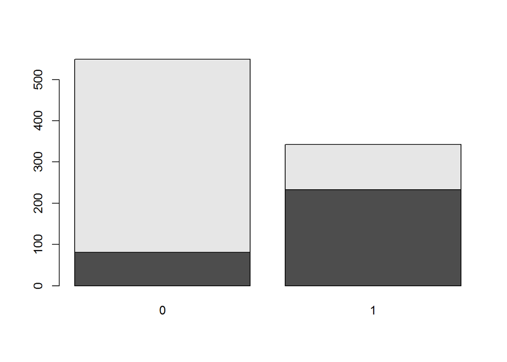

```r
barplot(table(titanic$Sex, titanic$Survived))
```

Os resultados obtidos são de grande valor pois há muito a ser entendo sobre o naufrágio com esses dados. Primeiramente o fato de somente 38.38% das pessoas sobreviveram ao desastre, e entre essas 38.38%, 26.15% eram mulheres e somente 12.23% eram homens. Para analizar os dados de forma mais individual, nota-se que 64.7% da população do Titanic era Masculina e sómente 35.3% era feminina.

Entre os Homens, somente 18.89% deles sobreviveram, diferentemente do dado coletado no dataset “female” que 74.2% das Mulheres sobreviveram! Resultado muito interessante pelo fato de ter um diferença tao grande.

O Grafico demonstra esta diferença, mostrando em tom claro os Homens e em tom escuro as Mulheres. (dados tendo em vista que 1 é verdadeiro com o termo “sobreviventes”)

Tendo em vista desta diferença, é interessante fazer o mesmo estudo em relação a idade das pessoas embarcadas.

```r
prop.table(table(criancas$Survived))*100
```

```
##
##    0    1
## 32.5 67.5
```

```r
prop.table(table(criancas$Sex, criancas$Survived)) *100
```

```
##
##             0    1
##   female 12.5 30.0
##   male   20.0 37.5
```

```r
prop.table(table(adultos$Survived))*100
```

```
##
##        0        1
## 61.61616 38.38384
```

```r
prop.table(table(adultos$Sex, adultos$Survived)) *100
```

```
##
##                  0         1
##   female  9.090909 26.150393
##   male   52.525253 12.233446
```

```r
prop.table(table(idosos$Survived))*100
```

```
##
##    0    1
## 87.5 12.5
```

```r
prop.table(table(idosos$Sex, idosos$Survived)) *100
```

```
##
##             0    1
##   female  0.0  0.0
##   male   87.5 12.5
```

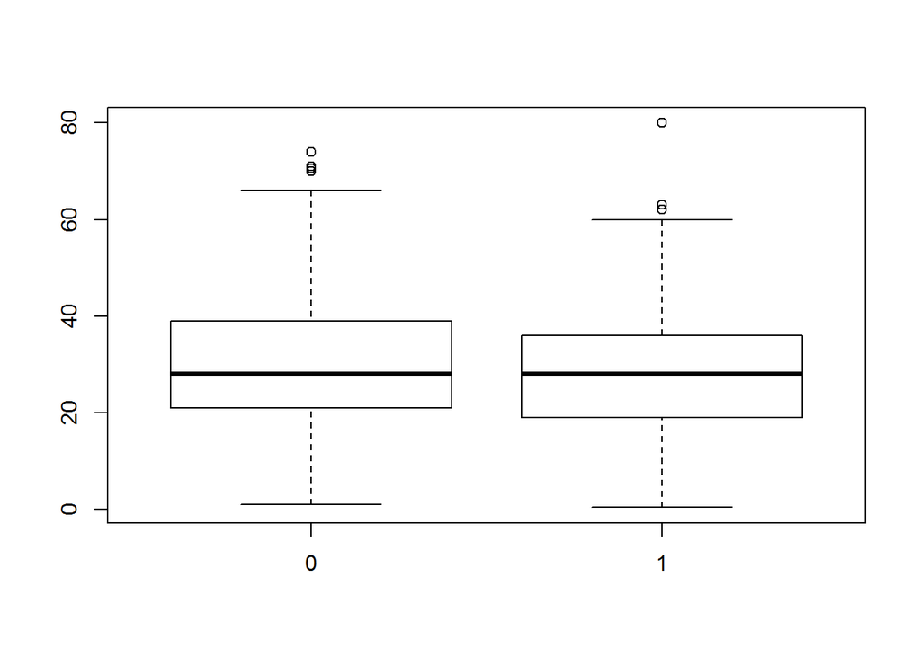

```r
boxplot(titanic$Age ~ titanic$Survived)
```

Este resultado demonstrou que 67.5% das pessoas com menos de 5 anos na época, foram salvas, e curiosamente, diferente do resultado com todos passageiros,o fato de ser do sexo masculo ou feminino não importou tanto para essa categoria. As porcentagens obtidas pelo estudo foram de que 67.5% dos sobreviventes com idade menos que 5 anos, 30% era do sexo feminino e 37.5% do sexo masculino. Uma diferença basicamente irrelevante ao comparar que havia mais homens do que mulheres no local.

Curiosamente o grupo de “idosos” (maior que 65 anos) só havia homens e somente 12.5% deles sobreviveram.

```r
prop.table(table(titanic$Pclass, titanic$Survived)) *100
```

```
##
##             0         1
##   1  8.978676 15.263749
##   2 10.886644  9.764310
##   3 41.750842 13.355780
```

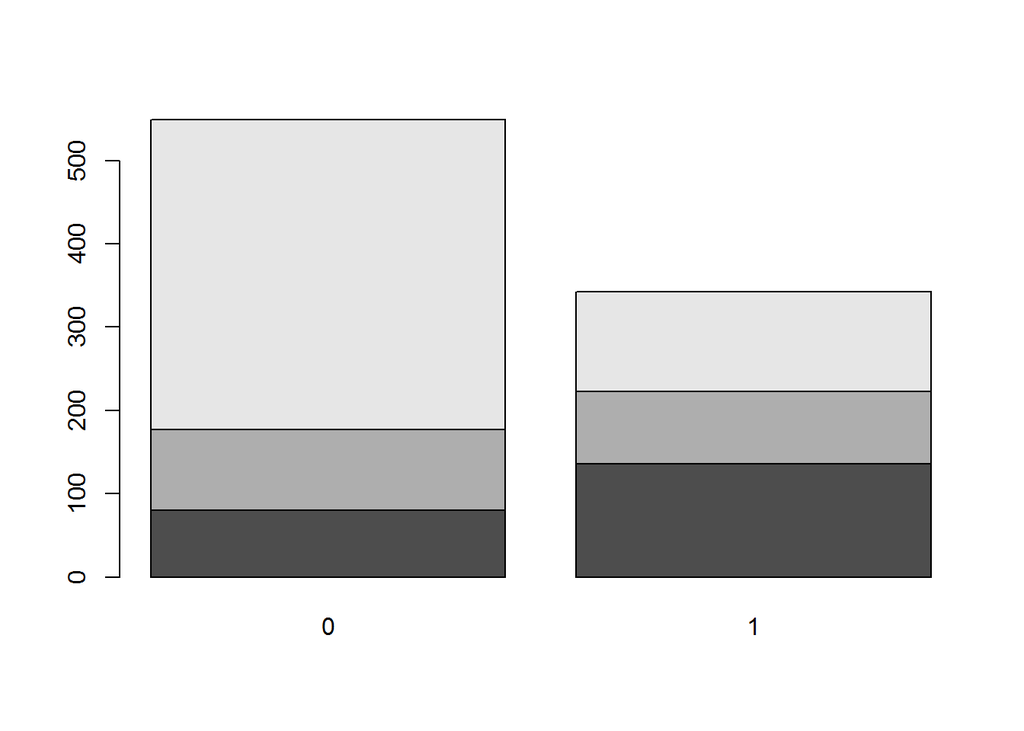

```r
barplot(table(titanic$Pclass, titanic$Survived))
```

Com essa análise exploratória, é possivel fazer uma conclusão que a maior porcentagem de sobreviventes foram as mulheres, as crianças e as pessoas que estavam na primeira classe.